# Detection mode project: Tables and figures for publication

Author

Martina Brayley

Published

October 5, 2024

version 5 - Using data missing as a separate category in analysis

version 6 - swapping HRT variable for HRT subtypes variable

# 1 Table and figure structure:

**Main tables**

Table 1 - general descriptives (population characteristics)

Table 2 - Risk factor descriptives by detection mode with logistic regression results from default model ( adjusted for multiple exposures and selected covariates) + model additionally adjusted for mammo density (add mediation measure)

**Main figures**

Figures 1 to 3 - comprised figure of plots describing mamographic density in relation to risk factors (detail in ST 2)

**Supplementary material**

(ST = Supplementary Table)

ST 1 - TC descriptives by detection mode with logistic regression results for TC only + full model RF adjusting for TC + fulll RFmodel adjusting for TC and density

ST 2 - difference in characteristics between those with and without mammographic density

# 2 Main figures and tables

## 2.1 Table 1 - Participant characteristics by detection mode

by detection mode and with p-value from logistic regression model with tumour characteristics in the model (from supplementary table 1) + adjusted for time variables

| **Characteristic** | **I**, N = 755 <sup>1</sup> | **SD**, N = 1,185 <sup>1</sup> | **p-value** <sup>2</sup> |
| --- | --- | --- | --- |
| Age at diagnosis | 61.83 (6.79) | 61.11 (6.39) | 0.4 |
| Age at recruitment | 54.65 (7.10) | 54.69 (6.94) | 0.3 |
| Time from recruitment to diagnosis | 7.19 (3.69) | 6.42 (3.58) | 0.2 |
| Year of diagnosis |  |  |  |
| 2004-2008 | 96 (13) | 182 (15) |  |
| 2009-2013 | 255 (34) | 496 (42) | 0.3 |
| 2014-2018 | 404 (54) | 507 (43) | >0.9 |
| Invasive status |  |  |  |
| 0 | 47 (6.2) | 261 (22) |  |
| 1 | 708 (94) | 924 (78) | 0.082 |
| Grade |  |  |  |
| 1 | 88 (12) | 250 (21) |  |
| 2 | 335 (44) | 477 (40) | 0.006 |
| 3 | 264 (35) | 187 (16) | <0.001 |
| Missing | 68 (9.0) | 271 (23) | 0.026 |
| Morphology type |  |  |  |
| Ductal | 549 (73) | 698 (59) |  |
| Lobular | 95 (13) | 119 (10) | 0.8 |
| Mixed: ductal and other | 25 (3.3) | 43 (3.6) | 0.8 |
| Other | 39 (5.2) | 64 (5.4) | 0.7 |
| Missing | 47 (6.2) | 261 (22) |  |
| Positive nodes |  |  |  |
| Negative | 304 (40) | 601 (51) |  |
| Positive | 234 (31) | 194 (16) | <0.001 |
| Missing | 217 (29) | 390 (33) | <0.001 |
| Tumour size |  |  |  |
| <21 | 336 (45) | 656 (55) |  |
| 21-50 | 225 (30) | 162 (14) | <0.001 |
| 50+ | 31 (4.1) | 15 (1.3) | 0.004 |
| Missing | 163 (22) | 352 (30) | 0.009 |
| ER status |  |  |  |
| Positive | 525 (70) | 791 (67) |  |
| Negative | 137 (18) | 87 (7.3) | 0.006 |
| Missing | 93 (12) | 307 (26) | 0.7 |
| PR status |  |  |  |
| Positive | 283 (37) | 375 (32) |  |
| Negative | 175 (23) | 154 (13) | 0.3 |
| Missing | 297 (39) | 656 (55) | 0.016 |
| HER2 status |  |  |  |
| Positive | 102 (14) | 92 (7.8) |  |
| Negative | 524 (69) | 725 (61) | >0.9 |
| Missing | 129 (17) | 368 (31) | 0.8 |

<sup>1</sup> Mean (SD); n (%)  
<sup>2</sup> p-value from logistic regression multivariate model of all listed variables

#### 2.2.0.1 Data transformation - formal statistical test of differences between categories

29/07/2024 decided to use square root transformation as data not normally distributed. Linear regression is then used to and p-values (what about estimate?) will be then added to the figures.

#### 2.2.0.2 Distribution before and after transformation

Figure for internal info only - data approximately normally distributed with more symmetry (checked with Michael and agreed this is appropriate for linear regression)

Notes: full code with more formal tests and distribution descriptives is in general_descriptives.qmd file

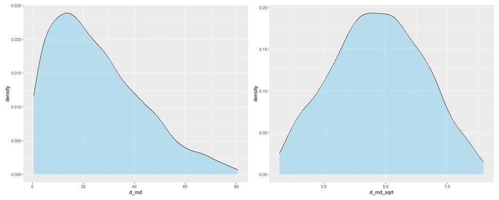

**Note**

### 2.2.1 Reproductive, lifestyle and other risk factors

plot list:

plot 1 - detection mode

plot 2 - Meno status

plot 3 - age meno

plot 4 - HRT

plot 5 - n of parous preg

plot 6 - age at first birth

plot 7 - Age at menarche

plot 8 - Oral contraceptives

plot 9 - BBD

plot 10 - Family history of BC

plot 11 - Alcohol

plot 12 - Smoking status

plot 13 - BMI entry

plot 14 - physical activity

plot 15 - Breastfeeding duration

plot 16 - BMI age 20

#### 2.2.1.1 Ordering for RF plots

(chronological order)

Composite plot 1

plot 7 - Age at menarche

plot 8 - Oral contraceptives

Composite plot 2

plot 5 - n of parous preg

plot 6 - age at first birth

plot 15 - Breastfeeding duration

Composite plot 3

plot 2 - Meno status

plot 3 - age meno

plot 4 - HRT

Composite plot 4

plot 9 - BBD

plot 10 - Family history of BC

Composite plot 5

plot 16 - BMI age 20

plot 13 - BMI entry

plot 14 - physical activity

Composite plot 6

plot 11 - Alcohol

plot 12 - Smoking status

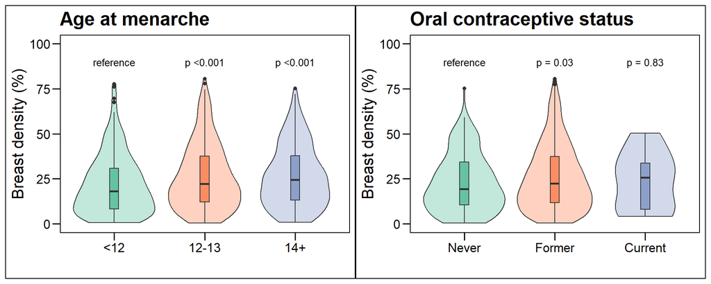

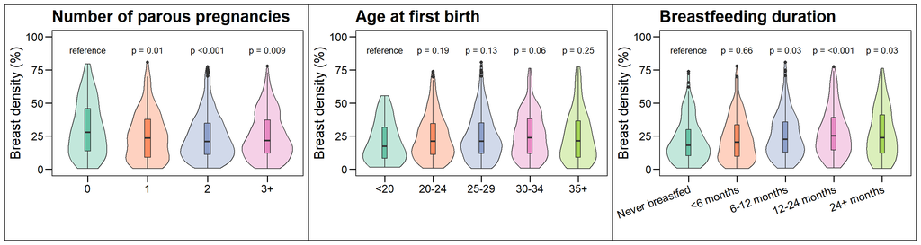

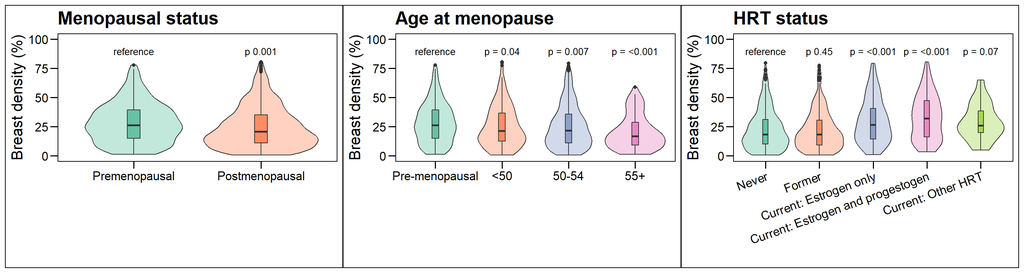

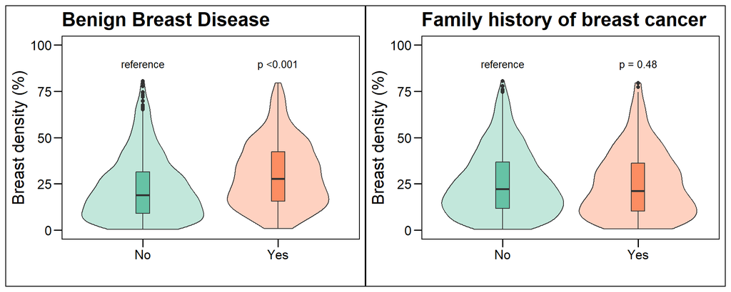

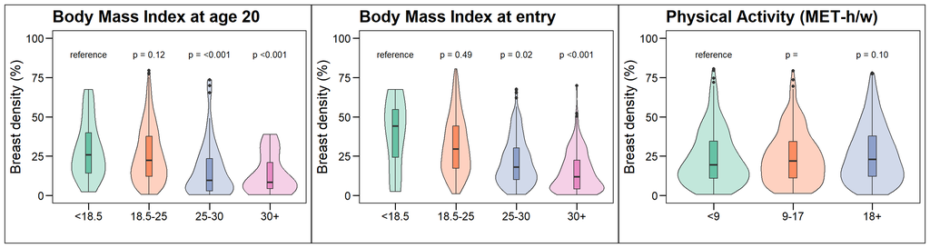

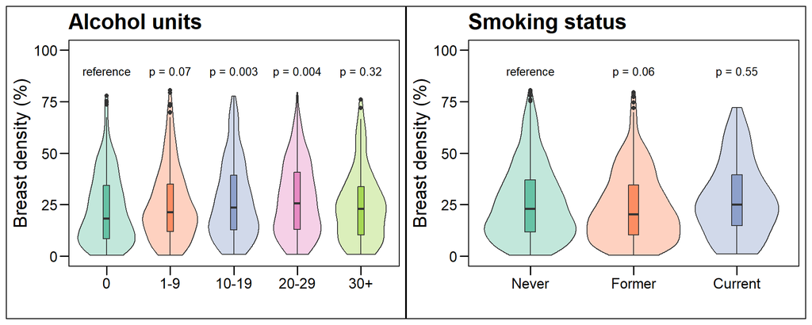

### 2.2.2 old plots

### 2.2.3 Tumour characteristics

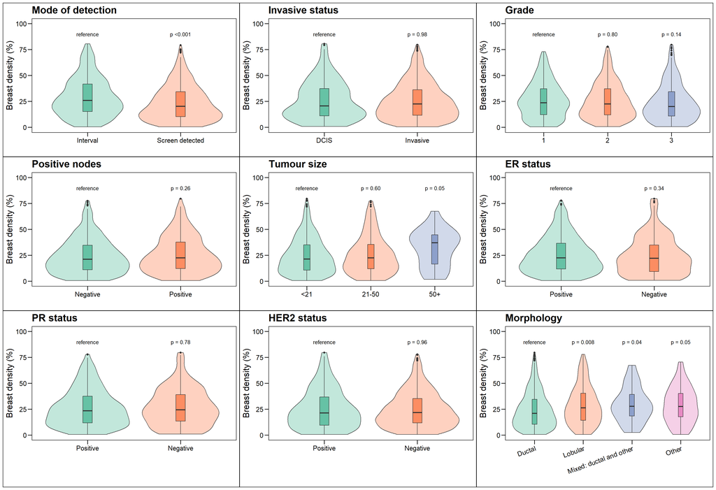

## 2.3 Table 2 - Main analysis

The main analysis is a logistic regression with multiple exposures (risk factors).

This table shows risk factor level descriptives and their associations with the mode of detection (logistic regression) adjusted for all other risk factors, age at diagnosis and time from entry to BC diagnosis.

Model 2 is the final selected model (Default model) to present in the analysis. Model 2 is adjusted for all co-exposures + age at diagnosis and time from entry to BC diagnosis. Model 1 was only adjusted for co-exposures, e.i. all exposures in the model.

Because model 2 was selected as the default model, it is also used on the subanalyses with TC and MD as the comparison against adjusted models for TC and MD.

03/10/2024 - adding breastfeeding and BMI age 20 to the models, changed OC status to never/ever

**Model 1**: “d_R1alcohol_status_cat”, “d_R1alcohol_units_cat”, “d_R1smokingstatus_cat”, “d_bmi_entry_cat”, “d_R1physmet_leis_who”, “d_bbd”, “d_fambrca”, “d_age_menarche_cat”, “d_ocstatus_cat”, “d_R1menopause_cat3”, “d_age_menopause_cat”, “d_R1hrtstatus_cat”, “d_parous_cat”, “d_parity_cat”, “d_agebirth1_cat” + breastfeeding duration + bmi at 20

**Model 2**: Model 1 + “diagage”, “d_R1toBC_y”, “yeardiag”

**Model 3:** Model 2 + “d_md_qrt”

**Model 4:** Model 3 + d_MDtoBC_lab (categorical)

### 2.3.1 Detailed table - internal use only

| **Characteristic** | **Distribution by detection mode** **I**, N = 755 <sup>1</sup> | **Distribution by detection mode** **SD**, N = 1,185 <sup>1</sup> | **Model 2** **OR** <sup>2,3</sup> | **Model 2** **95% CI** <sup>3</sup> | **Model 2** **p-value** | **Model 4** **OR** <sup>4,3</sup> | **Model 4** **95% CI** <sup>3</sup> | **Model 4** **p-value** |
| --- | --- | --- | --- | --- | --- | --- | --- | --- |
| Age at menarche |  |  |  |  |  |  |  |  |
| <12 | 153 (20) | 260 (22) | — | — |  | — | — |  |
| 12-13 | 369 (49) | 523 (44) | 1.19 | 0.93, 1.54 | 0.2 | 1.13 | 0.87, 1.46 | 0.4 |
| 14+ | 169 (22) | 286 (24) | 0.90 | 0.67, 1.21 | 0.5 | 0.86 | 0.64, 1.17 | 0.3 |
| Missing | 64 (8.5) | 116 (9.8) | 0.95 | 0.65, 1.38 | 0.8 | 0.84 | 0.57, 1.24 | 0.4 |
| Oral contraceptives status |  |  |  |  |  |  |  |  |
| Never | 95 (13) | 182 (15) | — | — |  | — | — |  |
| Former | 639 (85) | 967 (82) | 1.23 | 0.92, 1.66 | 0.2 | 1.28 | 0.95, 1.75 | 0.11 |
| Current | 20 (2.6) | 34 (2.9) | 1.13 | 0.58, 2.18 | 0.7 | 1.09 | 0.55, 2.13 | 0.8 |
| Missing | 1 (0.1) | 2 (0.2) | 1.73 | 0.07, 21.2 | 0.7 | 1.84 | 0.07, 24.6 | 0.7 |
| N of parous pregnancies |  |  |  |  |  |  |  |  |
| 0 | 97 (13) | 161 (14) | — | — |  | — | — |  |
| 1 | 86 (11) | 125 (11) | 1.34 | 0.70, 2.54 | 0.4 | 1.49 | 0.76, 2.90 | 0.2 |
| 2 | 408 (54) | 630 (53) | 1.21 | 0.68, 2.16 | 0.5 | 1.33 | 0.72, 2.43 | 0.4 |
| 3+ | 164 (22) | 269 (23) | 1.13 | 0.62, 2.04 | 0.7 | 1.27 | 0.68, 2.35 | 0.5 |
| Age at first birth |  |  |  |  |  |  |  |  |
| <20 | 35 (4.6) | 45 (3.8) | — | — |  | — | — |  |
| 20-24 | 197 (26) | 308 (26) | 0.83 | 0.50, 1.38 | 0.5 | 0.79 | 0.47, 1.35 | 0.4 |
| 25-29 | 256 (34) | 421 (36) | 0.76 | 0.46, 1.26 | 0.3 | 0.73 | 0.44, 1.24 | 0.2 |
| 30-34 | 122 (16) | 174 (15) | 0.86 | 0.50, 1.50 | 0.6 | 0.86 | 0.49, 1.52 | 0.6 |
| 35+ | 46 (6.1) | 71 (6.0) | 0.80 | 0.42, 1.51 | 0.5 | 0.81 | 0.42, 1.55 | 0.5 |
| Missing | 99 (13) | 166 (14) | 0.48 | 0.06, 2.60 | 0.4 | 0.43 | 0.05, 2.52 | 0.4 |
| Cummulative breastfeeding duration |  |  |  |  |  |  |  |  |
| Never breastfed | 101 (13) | 179 (15) | — | — |  | — | — |  |
| <6 months | 223 (30) | 319 (27) | 1.23 | 0.90, 1.69 | 0.2 | 1.23 | 0.89, 1.70 | 0.2 |
| 6-12 months | 131 (17) | 200 (17) | 1.12 | 0.79, 1.59 | 0.5 | 1.13 | 0.79, 1.62 | 0.5 |
| 12-24 months | 131 (17) | 244 (21) | 0.93 | 0.65, 1.32 | 0.7 | 0.86 | 0.60, 1.24 | 0.4 |
| 24+ months | 72 (9.5) | 82 (6.9) | 1.47 | 0.94, 2.30 | 0.092 | 1.44 | 0.91, 2.28 | 0.12 |
| Missing | 97 (13) | 161 (14) |  |  |  |  |  |  |
| Menopause |  |  |  |  |  |  |  |  |

[output cut: 54 more lines]

<sup>1</sup> n (%)  
<sup>2</sup> Model 2: Age at menarche, Menopause, Age at menopause, HRT status, Oral contraceptives status, N of parous pregnancies, Age at first birth, Cummulative breastfeeding duration, Benign breast disease, Family history of BC, BMI at entry, BMI at age 20y, Leisure Physical Activity (MET-h/w), Alcohol units per week, Smoking status, Age at Diagnosis, Time from Recruitment to BC diagnosis, Year of diagnosis  
<sup>3</sup> OR = Odds Ratio, CI = Confidence Interval  
<sup>4</sup> Model 4: Age at menarche, Menopause, Age at menopause, HRT status, Oral contraceptives status, N of parous pregnancies, Age at first birth, Cummulative breastfeeding duration, Benign breast disease, Family history of BC, BMI at entry, BMI at age 20y, Leisure Physical Activity (MET-h/w), Alcohol units per week, Smoking status, Age at Diagnosis, Time from Recruitment to BC diagnosis, Year of diagnosis Percent Mammographic density (quartiles), Time from Mammographic density measurement to BRCA diagnosis.

### 2.3.2 Simplified table

on 01/10/2024 agreed to:

- remove percentages
- use HRT simple variable (never/former/current)
- Use OC status simple variable (ever/never)
- remove p for categories
- add overall p-value (only for model 4?)

Forest plot will be also presented

| **Characteristic** | **Distribution by detection mode** **I**, N = 755 <sup>1</sup> | **Distribution by detection mode** **SD**, N = 1,185 <sup>1</sup> | **Model 2** **OR** <sup>2,3</sup> | **Model 2** **95% CI** <sup>3</sup> | **Model 2** **p-value** | **Model 4** **OR** <sup>4,3</sup> | **Model 4** **95% CI** <sup>3</sup> | **Model 4** **p-value** |
| --- | --- | --- | --- | --- | --- | --- | --- | --- |
| Age at menarche |  |  |  |  | 0.10 |  |  | 0.3 |
| <12 | 153 | 260 | — | — |  | — | — |  |
| 12-13 | 369 | 523 | 1.19 | 0.92, 1.53 |  | 1.15 | 0.82, 1.64 |  |
| 14+ | 169 | 286 | 0.89 | 0.67, 1.20 |  | 0.86 | 0.57, 1.28 |  |
| Missing | 64 | 116 | 0.94 | 0.64, 1.37 |  | 1.21 | 0.72, 2.01 |  |
| Oral contraceptives status |  |  |  |  | 0.4 |  |  | 0.3 |
| No | 95 | 182 | — | — |  | — | — |  |
| Yes | 659 | 1,001 | 1.23 | 0.92, 1.66 |  | 1.28 | 0.87, 1.89 |  |
| Missing | 1 | 2 | 1.93 | 0.08, 22.7 |  | 3.75 | 0.13, 110 |  |
| N of parous pregnancies |  |  |  |  | 0.8 |  |  | 0.9 |
| 0 | 97 | 161 | — | — |  | — | — |  |
| 1 | 86 | 125 | 1.34 | 0.70, 2.55 |  | 1.29 | 0.53, 3.12 |  |
| 2 | 408 | 630 | 1.22 | 0.68, 2.18 |  | 1.38 | 0.61, 3.07 |  |
| 3+ | 164 | 269 | 1.13 | 0.62, 2.05 |  | 1.34 | 0.58, 3.06 |  |
| Age at first birth |  |  |  |  | 0.8 |  |  | >0.9 |
| <20 | 35 | 45 | — | — |  | — | — |  |
| 20-24 | 197 | 308 | 0.83 | 0.50, 1.39 |  | 0.75 | 0.37, 1.55 |  |
| 25-29 | 256 | 421 | 0.76 | 0.46, 1.27 |  | 0.82 | 0.41, 1.69 |  |
| 30-34 | 122 | 174 | 0.86 | 0.50, 1.49 |  | 0.91 | 0.43, 1.96 |  |
| 35+ | 46 | 71 | 0.80 | 0.43, 1.52 |  | 0.96 | 0.40, 2.33 |  |
| Missing | 99 | 166 | 0.48 | 0.06, 2.61 |  | 0.51 | 0.05, 3.66 |  |
| Cummulative breastfeeding duration |  |  |  |  | 0.11 |  |  | 0.3 |
| Never breastfed | 101 | 179 | — | — |  | — | — |  |
| <6 months | 223 | 319 | 1.24 | 0.91, 1.69 |  | 1.24 | 0.81, 1.90 |  |
| 6-12 months | 131 | 200 | 1.12 | 0.79, 1.59 |  | 1.06 | 0.66, 1.71 |  |
| 12-24 months | 131 | 244 | 0.93 | 0.65, 1.32 |  | 0.97 | 0.60, 1.59 |  |
| 24+ months | 72 | 82 | 1.48 | 0.95, 2.32 |  | 1.66 | 0.88, 3.13 |  |
| Missing | 97 | 161 |  |  |  |  |  |  |
| Menopause |  |  |  |  | 0.2 |  |  | 0.3 |
| Premenopausal | 242 | 355 | — | — |  | — | — |  |

[output cut: 51 more lines]

<sup>1</sup> n  
<sup>2</sup> Model 2: Age at menarche, Menopause, Age at menopause, HRT status, Oral contraceptives status, N of parous pregnancies, Age at first birth, Cummulative breastfeeding duration, Benign breast disease, Family history of BC, BMI at entry, BMI at age 20y, Leisure Physical Activity (MET-h/w), Alcohol units per week, Smoking status, Age at Diagnosis, Time from Recruitment to BC diagnosis, Year of diagnosis  
<sup>3</sup> OR = Odds Ratio, CI = Confidence Interval  
<sup>4</sup> Model 4: Age at menarche, Menopause, Age at menopause, HRT status, Oral contraceptives status, N of parous pregnancies, Age at first birth, Cummulative breastfeeding duration, Benign breast disease, Family history of BC, BMI at entry, BMI at age 20y, Leisure Physical Activity (MET-h/w), Alcohol units per week, Smoking status, Age at Diagnosis, Time from Recruitment to BC diagnosis, Year of diagnosis Percent Mammographic density (quartiles), Time from Mammographic density measurement to BRCA diagnosis.

## 2.4 Figure X - forest plot

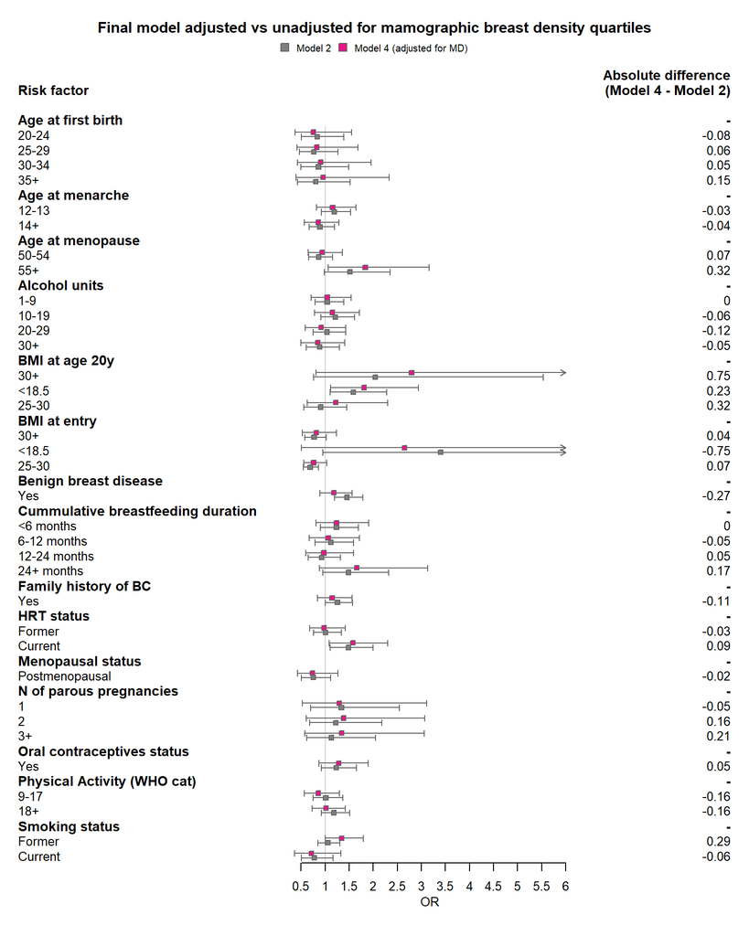

Note:

Some edits in the forest plot are still needed

- ordering on the forest plot to be fixed - each row in the plot is also a row in the data behind the plot so not easily sorted by variable

- BMI categories also jumped but reference is normal weight

- scale even when specific ticks selected it still defaults to ticks by 0.5 points

# 3 Supplementary material

## 3.1 ST 1 - TC descriptives and association with detection mode

TC descriptives by detection mode, logistic regression of TC with detection mode (same principal as risk factor analysis but multiple exposures are TC)

**Note**

this will be in excel format in supplement

| **Characteristic** | **Distribution by detection mode** **I**, N = 755 <sup>1</sup> | **Distribution by detection mode** **SD**, N = 1,185 <sup>1</sup> | **Model: TC only** **OR** <sup>2</sup> | **Model: TC only** **95% CI** <sup>2</sup> | **Model: TC only** **p-value** | **Model: TC + RF + time variables** **OR** <sup>2</sup> | **Model: TC + RF + time variables** **95% CI** <sup>2</sup> | **Model: TC + RF + time variables** **p-value** | **Model: TC + RF + MD + time variables** **OR** <sup>2</sup> | **Model: TC + RF + MD + time variables** **95% CI** <sup>2</sup> | **Model: TC + RF + MD + time variables** **p-value** |
| --- | --- | --- | --- | --- | --- | --- | --- | --- | --- | --- | --- |
| Invasive status |  |  |  |  |  |  |  |  |  |  |  |
| 0 | 47 (6.2) | 261 (22) | — | — |  | — | — |  | — | — |  |
| 1 | 708 (94) | 924 (78) | 1.56 | 0.90, 2.71 | 0.11 | 1.47 | 0.83, 2.62 | 0.2 | 1.52 | 0.84, 2.75 | 0.2 |
| Grade |  |  |  |  |  |  |  |  |  |  |  |
| 1 | 88 (12) | 250 (21) | — | — |  | — | — |  | — | — |  |
| 2 | 335 (44) | 477 (40) | 1.56 | 1.15, 2.12 | 0.004 | 1.65 | 1.20, 2.28 | 0.002 | 1.69 | 1.22, 2.35 | 0.002 |
| 3 | 264 (35) | 187 (16) | 2.41 | 1.69, 3.45 | <0.001 | 2.93 | 2.01, 4.28 | <0.001 | 3.08 | 2.09, 4.54 | <0.001 |
| Missing | 68 (9.0) | 271 (23) | 2.52 | 1.09, 6.12 | 0.035 | 2.88 | 1.21, 7.23 | 0.020 | 2.72 | 1.12, 7.02 | 0.031 |
| Morphology type |  |  |  |  |  |  |  |  |  |  |  |
| Ductal | 549 (73) | 698 (59) | — | — |  | — | — |  | — | — |  |
| Lobular | 95 (13) | 119 (10) | 0.94 | 0.67, 1.31 | 0.7 | 0.94 | 0.66, 1.34 | 0.7 | 0.88 | 0.61, 1.26 | 0.5 |
| Mixed: ductal and other | 25 (3.3) | 43 (3.6) | 0.92 | 0.53, 1.55 | 0.7 | 0.92 | 0.52, 1.62 | 0.8 | 0.90 | 0.50, 1.61 | 0.7 |
| Other | 39 (5.2) | 64 (5.4) | 0.89 | 0.55, 1.43 | 0.6 | 0.95 | 0.57, 1.56 | 0.8 | 0.88 | 0.53, 1.46 | 0.6 |
| Missing | 47 (6.2) | 261 (22) |  |  |  |  |  |  |  |  |  |
| Positive nodes |  |  |  |  |  |  |  |  |  |  |  |
| Negative | 304 (40) | 601 (51) | — | — |  | — | — |  | — | — |  |
| Positive | 234 (31) | 194 (16) | 1.67 | 1.29, 2.16 | <0.001 | 1.87 | 1.42, 2.46 | <0.001 | 1.85 | 1.40, 2.45 | <0.001 |
| Missing | 217 (29) | 390 (33) | 2.20 | 1.63, 2.97 | <0.001 | 2.38 | 1.73, 3.28 | <0.001 | 2.48 | 1.78, 3.45 | <0.001 |
| Tumour size |  |  |  |  |  |  |  |  |  |  |  |
| <21 | 336 (45) | 656 (55) | — | — |  | — | — |  | — | — |  |
| 21-50 | 225 (30) | 162 (14) | 2.12 | 1.63, 2.76 | <0.001 | 2.01 | 1.52, 2.66 | <0.001 | 2.07 | 1.56, 2.76 | <0.001 |
| 50+ | 31 (4.1) | 15 (1.3) | 3.11 | 1.60, 6.30 | 0.001 | 2.86 | 1.41, 6.01 | 0.004 | 2.76 | 1.34, 5.89 | 0.007 |
| Missing | 163 (22) | 352 (30) | 1.60 | 1.14, 2.27 | 0.007 | 1.64 | 1.14, 2.36 | 0.008 | 1.56 | 1.07, 2.27 | 0.022 |
| ER status |  |  |  |  |  |  |  |  |  |  |  |
| Positive | 525 (70) | 791 (67) | — | — |  | — | — |  | — | — |  |
| Negative | 137 (18) | 87 (7.3) | 1.68 | 1.14, 2.49 | 0.009 | 1.80 | 1.19, 2.71 | 0.005 | 1.71 | 1.12, 2.61 | 0.013 |
| Missing | 93 (12) | 307 (26) | 1.45 | 0.88, 2.37 | 0.14 | 1.17 | 0.69, 1.95 | 0.6 | 1.03 | 0.61, 1.74 | >0.9 |
| PR status |  |  |  |  |  |  |  |  |  |  |  |
| Positive | 283 (37) | 375 (32) | — | — |  | — | — |  | — | — |  |
| Negative | 175 (23) | 154 (13) | 0.86 | 0.61, 1.21 | 0.4 | 0.83 | 0.58, 1.20 | 0.3 | 0.79 | 0.54, 1.14 | 0.2 |

[output cut: 89 more lines]

<sup>1</sup> n (%)  
<sup>2</sup> OR = Odds Ratio, CI = Confidence Interval

## 3.2 ST 2 - Differences in characteristics between those with and without mammographic density

this table needs additional formatting changes, labels, add p-value for difference between groups, add time from entry to dg and age at diagnosis

any other variables to add or remove?

**Question**

Do we still need this table?

| **Characteristic** | **No**, N = 749 <sup>1</sup> | **Yes**, N = 1,191 <sup>1</sup> |
| --- | --- | --- |
| Mode of detection |  |  |
| I | 354 (47) | 401 (34) |
| SD | 395 (53) | 790 (66) |
| Menopause |  |  |
| Premenopausal | 364 (49) | 233 (20) |
| Postmenopausal | 385 (51) | 958 (80) |
| Age at menopause |  |  |
| <50 | 91 (12) | 210 (18) |
| 50-54 | 263 (35) | 639 (54) |
| 55+ | 31 (4.1) | 104 (8.7) |
| Missing | 364 (49) | 238 (20) |
| d_age_meno_cont | 50.28 (3.83) | 50.51 (3.93) |
| Unknown | 364 | 238 |
| d_R1hrtstatus_lab |  |  |
| Never | 162 (22) | 384 (32) |
| Former | 126 (17) | 316 (27) |
| Current | 95 (13) | 254 (21) |
| Missing | 366 (49) | 237 (20) |
| HRT status |  |  |
| Never | 162 (22) | 384 (32) |
| Former | 126 (17) | 316 (27) |
| Current: Estrogen only | 34 (4.5) | 103 (8.6) |
| Current: Estrogen and progestogen | 57 (7.6) | 133 (11) |
| Current: Other HRT | 4 (0.5) | 18 (1.5) |
| Missing | 366 (49) | 237 (20) |
| N of parous pregnancies |  |  |
| 0 | 104 (14) | 154 (13) |
| 1 | 74 (9.9) | 137 (12) |
| 2 | 410 (55) | 628 (53) |
| 3+ | 161 (21) | 272 (23) |

[output cut: 125 more lines]

<sup>1</sup> n (%); Mean (SD)